# Forecasting 2024 Global Happiness Trends: Exploring the Impact of Cumulative Socio-Economic Influences

#### Correlation between Life Expectancy and Happiness Scores

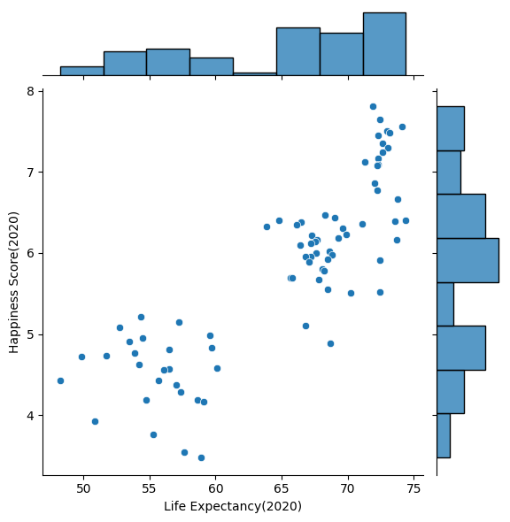

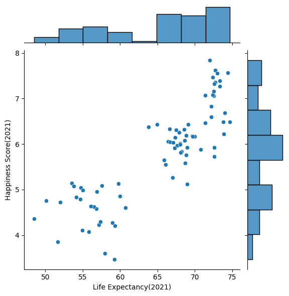

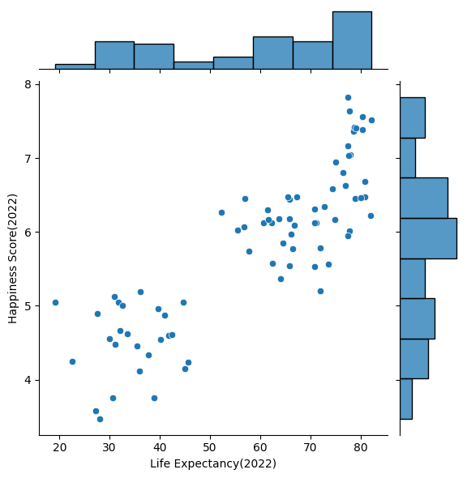

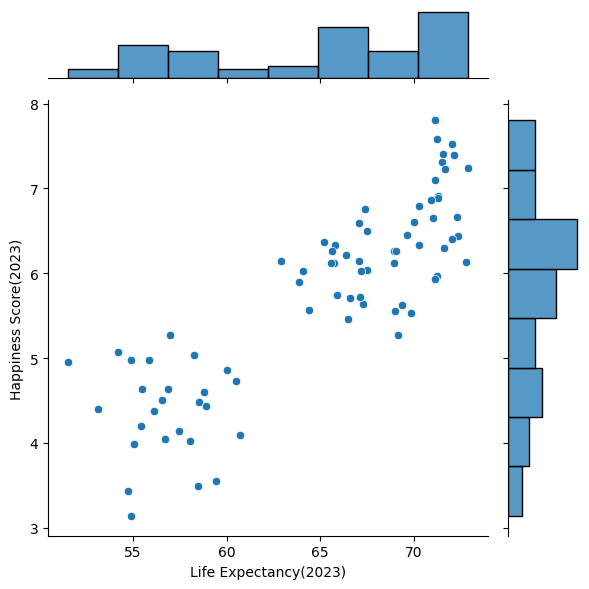

```python
# Plot the first jointplot
sns.jointplot(x='Life Expectancy(2020)', y='Happiness Score(2020)',
              data=merged_happiness_income_gdp_df, kind='scatter')

# Plot the second jointplot
sns.jointplot(x='Life Expectancy(2021)', y='Happiness Score(2021)',
              data=merged_happiness_income_gdp_df, kind='scatter')

# Plot the third jointplot
sns.jointplot(x='Life Expectancy(2022)', y='Happiness Score(2022)',
              data=merged_happiness_income_gdp_df, kind='scatter')

# Plot the fourth jointplot
sns.jointplot(x='Life Expectancy(2023)', y='Happiness Score(2023)',
              data=merged_happiness_income_gdp_df, kind='scatter')

# Remove extra whitespace between subplots
plt.tight_layout()

# Show the plot
plt.show()
```

**Interpretation:**

Upon examining the four joint plots displaying the relationship between 'Life Expectancy' and 'Happiness Score' across different years, a clear positive correlation emerges in all instances. The data points are clustered in a manner that indicates an upward trend, suggesting that as life expectancy increases, so does the happiness score. This consistent pattern underscores the significant influence of life expectancy on happiness levels over time. The observed positive correlation implies that improvements in life expectancy within the dataset are associated with higher reported levels of happiness. While other factors may also contribute to overall well-being, these findings emphasize the crucial role of health-related factors in shaping subjective happiness assessments. Such insights highlight the importance of investing in public health initiatives and healthcare systems to promote overall happiness and well-being within populations.

### Outlier Boxplots (2020-2023)

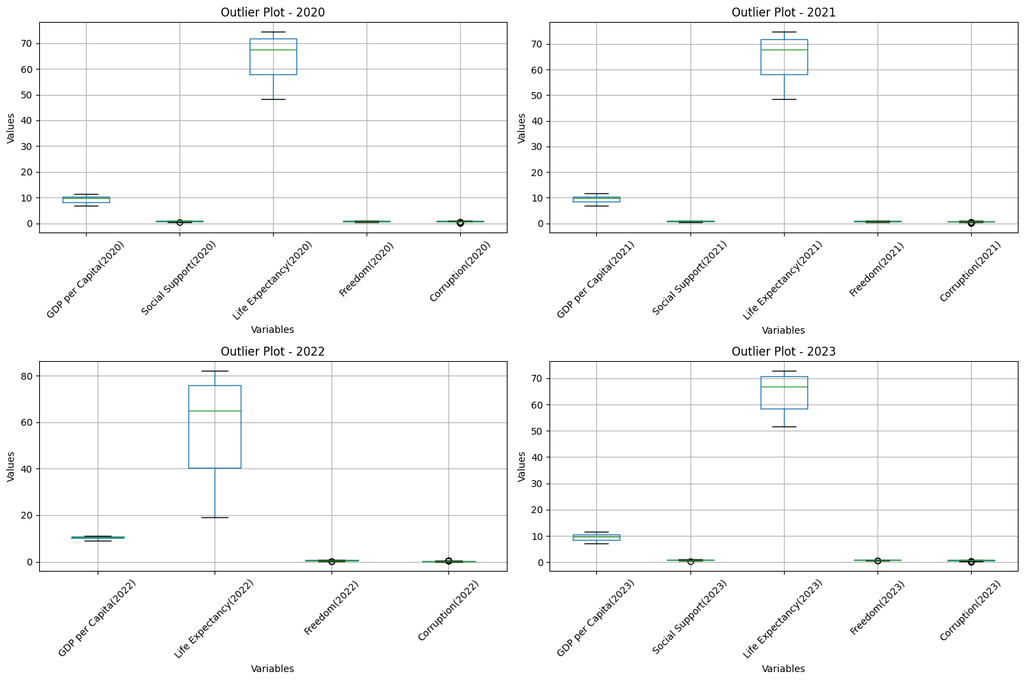

```python
# Select the variables for the outlier plot
variables_2020 = ['GDP per Capita(2020)', 'Social Support(2020)',
                  'Life Expectancy(2020)', 'Freedom(2020)', 'Corruption(2020)']
variables_2021 = ['GDP per Capita(2021)', 'Social Support(2021)',
                  'Life Expectancy(2021)', 'Freedom(2021)', 'Corruption(2021)']
variables_2022 = ['GDP per Capita(2022)', 'Social Support(2022)',
                  'Life Expectancy(2022)', 'Freedom(2022)', 'Corruption(2022)']
variables_2023 = ['GDP per Capita(2023)', 'Social Support(2023)',
                  'Life Expectancy(2023)', 'Freedom(2023)', 'Corruption(2023)']

# Create subplots for all four box plots
fig, axs = plt.subplots(2, 2, figsize=(15, 10))

# Plot boxplots for each year
for i, year in enumerate([variables_2020, variables_2021, variables_2022, variables_2023]):
    row = i // 2
    col = i % 2
    merged_happiness_income_gdp_df[year].boxplot(ax=axs[row, col])
    axs[row, col].set_title(f'Outlier Plot - {years[i]}')
    axs[row, col].set_xlabel('Variables')
    axs[row, col].set_ylabel('Values')
    axs[row, col].tick_params(axis='x', rotation=45)

plt.tight_layout()
plt.show()
```

**Interpretation:**

The boxplots generated from the provided code offer valuable insights into the distribution of various variables across four consecutive years. One notable observation is the consistent pattern observed across all four plots, where the variable representing life expectancy exhibits more significant variability compared to other variables. This finding suggests that life expectancy experiences wider fluctuations and possibly more extreme values over the years, as evidenced by the longer whiskers and larger interquartile range (IQR) in its boxplots. Such variability in life expectancy may indicate fluctuating health conditions or healthcare access across different regions or countries over the studied period. Understanding these fluctuations can be crucial for policymakers and public health authorities in identifying areas for targeted interventions aimed at improving overall population health and well-being. Further analysis and exploration into the underlying factors driving these fluctuations in life expectancy could provide valuable insights for designing effective health policies and interventions.

### Residual Plots (2020-2023)

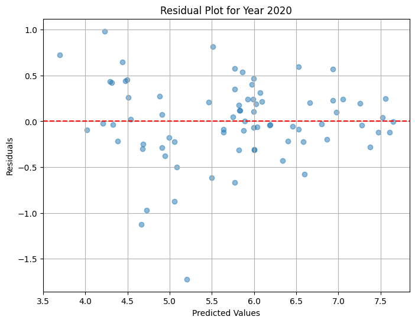

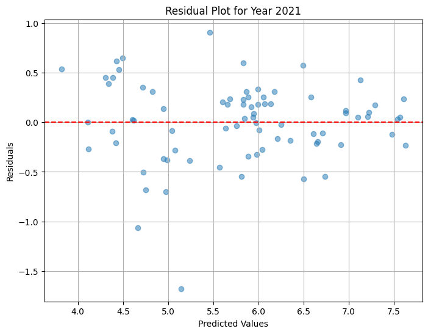

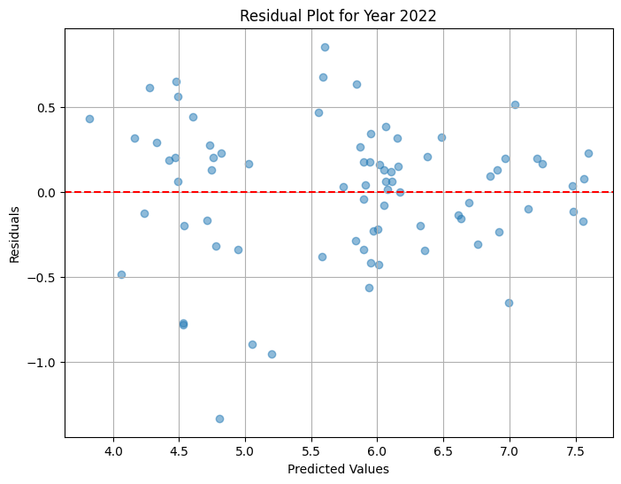

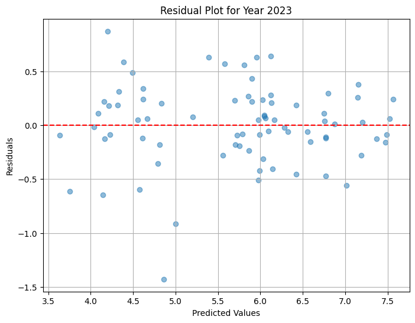

```python
# Loop through each year and generate residual plots
for year, independent_vars in zip(range(2020, 2024), [independent_vars_2020, independent_vars_2021, independent_vars_2022, independent_vars_2023]):
    X = merged_happiness_income_gdp_df[independent_vars].astype(
        float)  # Convert independent variables to float

    # Prepare the dependent variable
    y = merged_happiness_income_gdp_df[f'Happiness Score({year})'].astype(
        float)  # Convert dependent variable to float

    # Add a constant term to the independent variables
    X = sm.add_constant(X)

    # Fit the regression model
    model = sm.OLS(y, X)
    results = model.fit()

    # Generate predicted values
    predicted_values = results.predict(X)

    # Calculate residuals
    residuals = y - predicted_values

    # Create residual plot
    plt.figure(figsize=(8, 6))
    plt.scatter(predicted_values, residuals, alpha=0.5)
    # Add a horizontal line at y=0
    plt.axhline(y=0, color='red', linestyle='--')
    plt.title(f'Residual Plot for Year {year}')
    plt.xlabel('Predicted Values')
    plt.ylabel('Residuals')
    plt.grid(True)
    plt.show()
```

**Interpretation:** Upon examining the residual plots for the years 2020 to 2023, it is evident that the residuals are randomly scattered around the horizontal line at zero. This random distribution suggests that the linear regression models fitted to the data adequately capture the relationships between the independent variables (such as GDP per Capita, Social Support, Life Expectancy, Freedom, and Corruption) and the dependent variable (Happiness Score). The absence of any discernible pattern in the residuals indicates that the models are appropriately capturing the variation in the data, without any systematic bias or unexplained trends. Overall, the random scattering of residuals around the zero line signifies that the regression models provide a satisfactory fit to the data across the four years analyzed.

### Heatmaps (2020-2023)

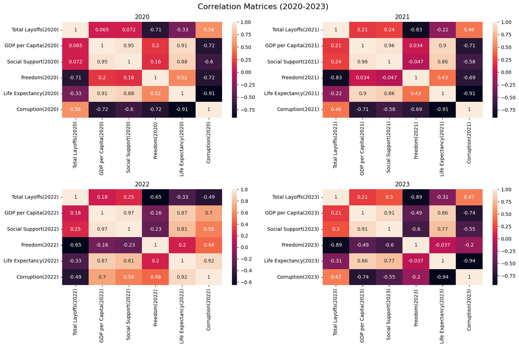

```python
# Visualize the four correlation matrices with a different color scheme
fig, axes = plt.subplots(2, 2, figsize=(15, 10))
fig.suptitle('Correlation Matrices (2020-2023)', fontsize=16)

# 2020
sns.heatmap(correlation_matrix_2020, annot=True, cmap='rocket', ax=axes[0, 0])
axes[0, 0].set_title('2020')

# 2021
sns.heatmap(correlation_matrix_2021, annot=True, cmap='rocket', ax=axes[0, 1])
axes[0, 1].set_title('2021')

# 2022
sns.heatmap(correlation_matrix_2022, annot=True, cmap='rocket', ax=axes[1, 0])
axes[1, 0].set_title('2022')

# 2023
sns.heatmap(correlation_matrix_2023, annot=True, cmap='rocket', ax=axes[1, 1])
axes[1, 1].set_title('2023')

# Adjust the layout
plt.tight_layout()
plt.show()
```

**Interpretation:**

## Comparative Analysis

### Scatter Plots (2020-2023)

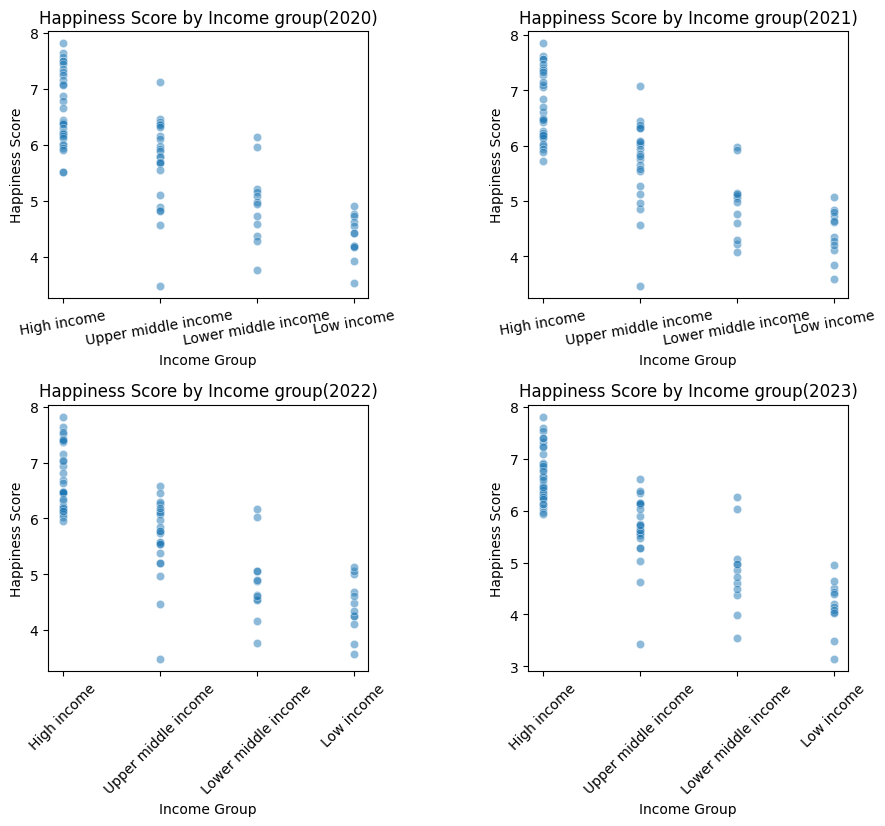

```python
# Create a figure and four subplots
fig, axes = plt.subplots(2, 2, figsize=(10, 8))

sns.scatterplot(x="Income Group", y="Happiness Score(2020)",
                sizes=(10, 40), alpha=.5,
                data=merged_happiness_income_gdp_df, ax=axes[0, 0])
axes[0, 0].set_title('Happiness Score by Income group(2020)')
axes[0, 0].set_xlabel('Income Group')
axes[0, 0].set_ylabel('Happiness Score')

# Plot the second subplot
sns.scatterplot(x="Income Group", y="Happiness Score(2021)",
                sizes=(10, 40), alpha=.5,
                data=merged_happiness_income_gdp_df, ax=axes[0, 1])
axes[0, 1].set_title('Happiness Score by Income group(2021)')
axes[0, 1].set_xlabel('Income Group')
axes[0, 1].set_ylabel('Happiness Score')

# Plot the third subplot
sns.scatterplot(x="Income Group", y="Happiness Score(2022)",
                sizes=(10, 40), alpha=.5,
                data=merged_happiness_income_gdp_df, ax=axes[1, 0])
axes[1, 0].set_title('Happiness Score by Income group(2022)')
axes[1, 0].set_xlabel('Income Group')
axes[1, 0].set_ylabel('Happiness Score')

# Plot the fourth subplot
sns.scatterplot(x="Income Group", y="Happiness Score(2023)",
                sizes=(10, 40), alpha=.5,
                data=merged_happiness_income_gdp_df, ax=axes[1, 1])
axes[1, 1].set_title('Happiness Score by Income group(2023)')
axes[1, 1].set_xlabel('Income Group')
axes[1, 1].set_ylabel('Happiness Score')

# Rotate the x-axis labels for better readability
axes[0, 0].tick_params(axis='x', rotation=10)
axes[0, 1].tick_params(axis='x', rotation=10)
axes[1, 0].tick_params(axis='x', rotation=45)
axes[1, 1].tick_params(axis='x', rotation=45)

# Adjust spacing between subplots
plt.subplots_adjust(left=0.1, right=0.9, top=0.9,
                    bottom=0.1, wspace=0.5, hspace=0.4)

# Show the plots
plt.show()
```

**Interpretation:**

The provided code generates a series of scatter plots illustrating the relationship between income groups and happiness scores across four consecutive years. Across all four scatter plots, a clear pattern emerges: countries categorized as high-income consistently exhibit the highest happiness scores, followed by upper-middle-income, lower-middle-income, and low-income countries. This consistent hierarchy suggests a robust correlation between income levels and happiness scores over the studied period. Interestingly, the pattern remains consistent despite potential fluctuations in global economic conditions or other external factors. Such findings underscore the significance of economic well-being in shaping overall happiness levels within different socio-economic contexts. Understanding these dynamics can inform policymakers and international organizations in designing targeted interventions aimed at improving overall happiness and well-being, particularly in low-income regions where happiness scores tend to be lower.

### Bar Plots (2020-2023)

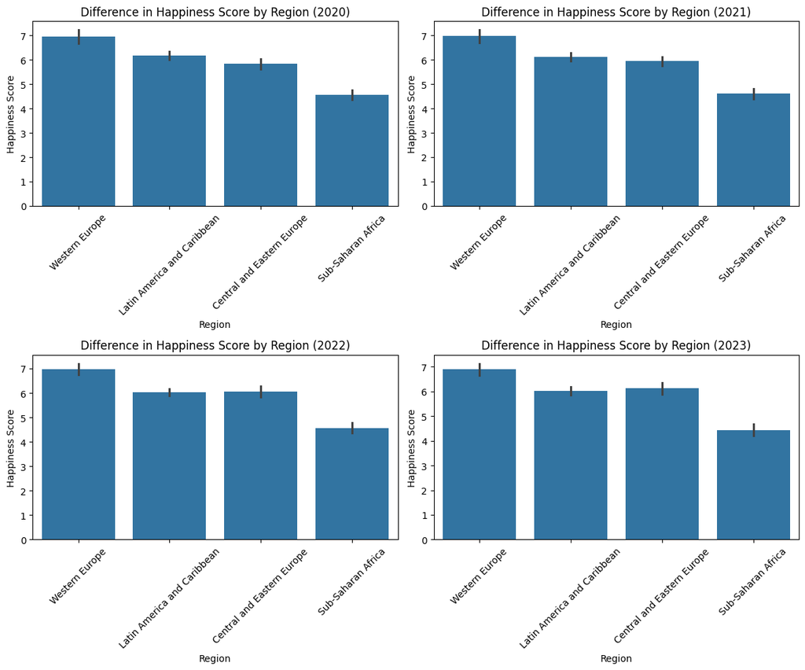

```python
# Create a figure and four subplots
fig, axes = plt.subplots(2, 2, figsize=(12, 10))

# Plot the first subplot
sns.barplot(x='Region', y='Happiness Score(2020)',
            data=merged_happiness_income_gdp_df, ax=axes[0, 0])
axes[0, 0].set_title('Difference in Happiness Score by Region (2020)')
axes[0, 0].set_xlabel('Region')
axes[0, 0].set_ylabel('Happiness Score')

# Plot the second subplot
sns.barplot(x='Region', y='Happiness Score(2021)',
            data=merged_happiness_income_gdp_df, ax=axes[0, 1])
axes[0, 1].set_title('Difference in Happiness Score by Region (2021)')
axes[0, 1].set_xlabel('Region')
axes[0, 1].set_ylabel('Happiness Score')

# Plot the third subplot
sns.barplot(x='Region', y='Happiness Score(2022)',
            data=merged_happiness_income_gdp_df, ax=axes[1, 0])
axes[1, 0].set_title('Difference in Happiness Score by Region (2022)')
axes[1, 0].set_xlabel('Region')
axes[1, 0].set_ylabel('Happiness Score')

# Plot the fourth subplot
sns.barplot(x='Region', y='Happiness Score(2023)',
            data=merged_happiness_income_gdp_df, ax=axes[1, 1])
axes[1, 1].set_title('Difference in Happiness Score by Region (2023)')
axes[1, 1].set_xlabel('Region')
axes[1, 1].set_ylabel('Happiness Score')

# Rotate the x-axis labels for better readability
for ax in axes.flat:
    ax.tick_params(axis='x', rotation=45)

# Adjust spacing between subplots
plt.tight_layout()

# Show the plots
plt.show()
```

**Interpretation:**

### Line Plots (2020-2023)

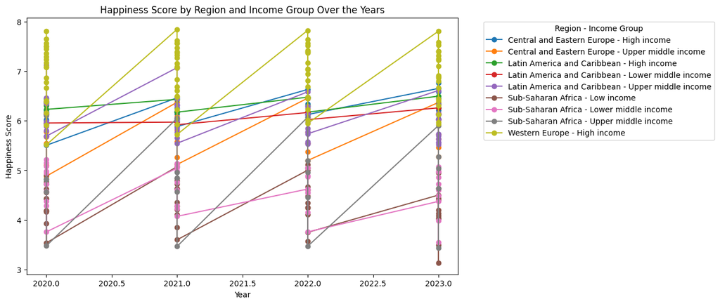

```python
# Reshape the DataFrame
merged_happiness_income_gdp_df_melted = pd.melt(merged_happiness_income_gdp_df, id_vars=['Region', 'Income Group'],
                                                value_vars=[
                                                    'Happiness Score(2020)', 'Happiness Score(2021)', 'Happiness Score(2022)', 'Happiness Score(2023)'],
                                                var_name='Year', value_name='Happiness Score')

# Extract the year from the ‘Year’ column and convert it to an integer
merged_happiness_income_gdp_df_melted['Year'] = merged_happiness_income_gdp_df_melted['Year'].str.extract(
    '(\d+)').astype(int)

# Create a line plot
fig, ax = plt.subplots(figsize=(10, 6))

# Loop through each region and income group and plot the data
for (region, income_group), group in merged_happiness_income_gdp_df_melted.groupby(['Region', 'Income Group']):
    group.plot(x='Year', y='Happiness Score', ax=ax,
               label=f"{region} - {income_group}", marker='o')

# Set the title, x-axis label, and y-axis label
plt.title('Happiness Score by Region and Income Group Over the Years')
plt.xlabel('Year')
plt.ylabel('Happiness Score')
plt.legend(title='Region - Income Group',
           bbox_to_anchor=(1.05, 1), loc='upper left')
plt.show()
```

**Interpretation:**

The line plot effectively captures and illustrates the relationship between regions and income groups in terms of their respective happiness scores over the years. Each line on the plot represents a specific combination of region and income group, allowing for a nuanced examination of how these factors interact to influence happiness levels. Upon observation, certain trends emerge. Generally, regions with higher income groups tend to exhibit higher happiness scores across the years, while regions with lower income groups show comparatively lower scores. However, there are exceptions and variations within regions, indicating that factors beyond income, such as social and cultural dynamics, also play significant roles in determining happiness levels. Additionally, over the years, some regions and income groups may experience fluctuations in happiness scores, reflecting changes in socio-economic conditions, policy interventions, or other external factors. Overall, the visualization highlights the complex interplay between region, income group, and happiness, underscoring the multifaceted nature of well-being and the need for comprehensive approaches to address global happiness disparities.

## Multivariate Analysis

### Cross-Tabulation (2020-2023)

```python
# Create a cross-tabulation to analyze the relationship between 'Region' and 'Income Group'
cross_tab = pd.crosstab(
    # Specify 'Region' as the rows (index)
    index=merged_happiness_income_gdp_df['Region'],
    # Specify 'Income Group' as the columns
    columns=merged_happiness_income_gdp_df['Income Group']
)
# Display the cross-tabulation results
cross_tab
```

| Income Group Region | High income | Low income | Lower middle income | Upper middle income |
| --- | --- | --- | --- | --- |
| Central and Eastern Europe | 8 | 0 | 0 | 6 |
| Latin America and Caribbean | 3 | 0 | 2 | 12 |
| Sub-Saharan Africa | 0 | 12 | 10 | 5 |
| Western Europe | 20 | 0 | 0 | 0 |

**Interpretation:**

Upon conducting a cross-tabulation analysis, it becomes evident that the distribution of income groups varies significantly across different regions. In Central and Eastern Europe, the majority of countries fall into the 'High income' and 'Upper middle income' categories, reflecting a relatively prosperous economic landscape. Conversely, in Sub-Saharan Africa, the predominant income groups are 'Low income' and 'Lower middle income,' indicating pervasive economic challenges within the region. Interestingly, Western Europe stands out as predominantly comprising 'High income' countries, suggesting a high level of economic prosperity across the region. Latin America and the Caribbean exhibit a more diverse distribution of income groups, with representation across 'High income,' 'Lower middle income,' and 'Upper middle income' categories. These findings underscore the intricate interplay between regional dynamics and income distribution, highlighting disparities that may inform targeted policy interventions aimed at promoting economic development and reducing inequality.

### Pivot Table (2020-2023)

```python
# Create pivot tables for each year
pivot_table_2020 = pd.pivot_table(merged_happiness_income_gdp_df, index='Region',
                                  columns='Income Group', values='Happiness Score(2020)', aggfunc='mean', fill_value=0)
pivot_table_2021 = pd.pivot_table(merged_happiness_income_gdp_df, index='Region',
                                  columns='Income Group', values='Happiness Score(2021)', aggfunc='mean', fill_value=0)
pivot_table_2022 = pd.pivot_table(merged_happiness_income_gdp_df, index='Region',
                                  columns='Income Group', values='Happiness Score(2022)', aggfunc='mean', fill_value=0)
pivot_table_2023 = pd.pivot_table(merged_happiness_income_gdp_df, index='Region',
                                  columns='Income Group', values='Happiness Score(2023)', aggfunc='mean', fill_value=0)

# Combine the pivot tables into one
combined_pivot_table = pd.concat([pivot_table_2020, pivot_table_2021, pivot_table_2022,
                                 pivot_table_2023], axis=1, keys=['2020', '2021', '2022', '2023'])

# Display the combined pivot table
combined_pivot_table
```

| Income Group Region | 2020 High income | 2020 Low income | 2020 Lower middle income | 2020 Upper middle income | 2021 High income | 2021 Low income | 2021 Lower middle income | 2021 Upper middle income | 2022 High income | 2022 Low income | 2022 Lower middle income | 2022 Upper middle income | 2023 High income | 2023 Low income | 2023 Lower middle income | 2023 Upper middle income |
| --- | --- | --- | --- | --- | --- | --- | --- | --- | --- | --- | --- | --- | --- | --- | --- | --- |
| Central and Eastern Europe | 6.045725 | 0.0000 | 0.00000 | 5.551300 | 6.139625 | 0.000000 | 0.0000 | 5.704500 | 6.301000 | 0.000000 | 0.0000 | 5.753000 | 6.387000 | 0.000000 | 0.0000 | 5.768333 |
| Latin America and Caribbean | 6.324467 | 0.0000 | 6.04515 | 6.153367 | 6.261000 | 0.000000 | 5.9455 | 6.105333 | 6.318333 | 0.000000 | 6.0935 | 5.949167 | 6.364333 | 0.000000 | 6.1410 | 5.923750 |
| Sub-Saharan Africa | 0.000000 | 4.3706 | 4.71087 | 4.758940 | 0.000000 | 4.423333 | 4.7346 | 4.779600 | 0.000000 | 4.432667 | 4.6097 | 4.830600 | 0.000000 | 4.170167 | 4.5598 | 4.855600 |
| Western Europe | 6.967405 | 0.0000 | 0.00000 | 0.000000 | 6.983850 | 0.000000 | 0.0000 | 0.000000 | 6.967100 | 0.000000 | 0.0000 | 0.000000 | 6.894350 | 0.000000 | 0.0000 | 0.000000 |

**Interpretation:**

Upon examining the combined pivot table encompassing mean happiness scores across income groups and regions for the years 2020 through 2023, intriguing insights emerge regarding the dynamics of happiness within diverse socio-economic contexts. Notably, within Central and Eastern Europe, countries classified as 'High income' and 'Upper middle income' consistently demonstrate elevated happiness scores, suggesting a positive correlation between economic prosperity and subjective well-being. In Latin America and the Caribbean, a remarkable stability in happiness scores is observed across income groups, indicative of a resilient societal fabric that transcends economic fluctuations. Conversely, Sub-Saharan Africa presents a sobering narrative, with uniformly lower happiness scores across income strata, underscoring persistent challenges to well-being irrespective of economic standing. Noteworthy is Western Europe's consistently high happiness scores, particularly evident among 'High income' nations, reflecting the region's robust socio-economic infrastructure conducive to overall life satisfaction. These findings collectively underscore the complex interplay between income, regional dynamics, and happiness, emphasizing the need for nuanced policy interventions to foster well-being across diverse global landscapes.

### Pair Plot (2020-2023)

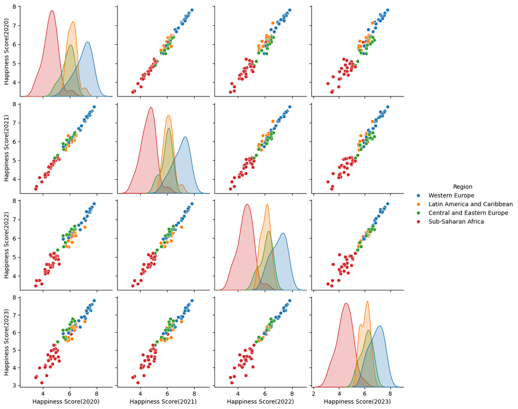

```python
# Create a pairplot to visualize the relationship between happiness scores
sns.pairplot(data=merged_happiness_income_gdp_df,
             hue="Region",
             vars=['Happiness Score(2020)', 'Happiness Score(2021)', 'Happiness Score(2022)', 'Happiness Score(2023)'])
```

**Interpretation:**

## Synthesis

### Descriptive Analysis

The descriptive analysis offers valuable insights into both labor market dynamics and socio-economic indicators across various countries and regions. From examining layoff statistics, we discern distinct patterns, revealing the economic resilience and labor market stability disparities across nations. Meanwhile, the summary statistics shed light on the socio-economic landscape, illustrating consistent trends in happiness scores, GDP per capita, life expectancy, and corruption perception. Moreover, the analysis of region-specific statistics unveils significant variations in subjective well-being and economic prosperity across different regions, underscoring disparities that may influence overall well-being and quality of life.

### Inferential Analysis

The inferential analysis, through regression models and ANOVA tests, delves deeper into the relationships between socio-economic factors and happiness scores over the years. It uncovers significant predictors of happiness, such as life expectancy, freedom, and corruption, underscoring their influence on subjective well-being. Furthermore, the analysis provides insights into the potential impact of socio-economic factors on layoff rates, highlighting the intricate interplay between economic variables and labor market dynamics.

### Graphical Analysis

Graphical analyses offer visual representations of complex relationships between variables, providing additional insights into the data. From scatter plots to box plots and correlation matrices, these visualizations reveal nuanced patterns and trends. Notably, they showcase the multifaceted nature of happiness determinants, the influence of income levels and regional dynamics on happiness scores, and the interplay between socio-economic variables and layoffs across different years.

### Comparative Analysis

Comparative analyses deepen our understanding of global happiness disparities, income distribution dynamics, and the complex relationships between region, income group, and happiness. They highlight consistent patterns in happiness levels across income groups and regions, emphasizing the significant role of economic well-being in shaping subjective well-being. Moreover, they underscore the need for nuanced policy interventions to address global happiness inequalities and foster well-being across diverse socio-economic contexts.

### Multivariate Analysis

The multivariate analysis offers a holistic view of the data by exploring the intricate interactions between multiple variables simultaneously. It uncovers complex relationships between income distribution, regional dynamics, and happiness, revealing disparities and trends that may inform targeted policy interventions. By considering regional nuances and income disparities, this analysis provides valuable insights for policymakers and stakeholders to design effective strategies aimed at promoting well-being and reducing inequality globally.

### Insights from Combined Datasets

The combination of datasets from diverse domains, including labor market statistics, socio-economic indicators, and happiness scores, provides a comprehensive understanding of global well-being and economic dynamics. By integrating disparate datasets, we gain insights and capabilities that would not be possible with individual datasets in isolation. This integrated approach allows for a nuanced exploration of the complex interconnections between socio-economic factors and subjective well-being, enabling policymakers and stakeholders to make informed decisions and interventions to enhance overall well-being and promote sustainable development globally.

### Summary

The comprehensive synthesis of descriptive, inferential, graphical, and multivariate analyses provides valuable insights into the complex interplay of socio-economic factors and their cumulative impact on global happiness trends. By integrating diverse datasets and methodologies, our analysis offers a nuanced understanding of how economic conditions, social welfare policies, and regional dynamics collectively shape subjective well-being. This holistic approach not only enriches our understanding of the factors driving happiness but also equips us with predictive capabilities to forecast future trends. By leveraging these insights, our research endeavors to address the central question of how cumulative socio-economic influences contribute to the forecasted happiness trends for the year 2024. Through informed policy recommendations and strategic interventions, we aim to contribute to the promotion of global well-being and societal resilience in the face of evolving socio-economic challenges.

## Reflection

Throughout our data analysis journey, we navigated various challenges and leveraged multiple strategies to extract meaningful insights from our datasets. The process involved meticulous data cleaning, transformative data frame manipulation, and thoughtful data visualization techniques. Each phase presented its own set of obstacles, but with collaborative effort and methodological rigor, we successfully overcame them to produce comprehensive analyses. Below, we delve into the specifics of each phase and reflect on the limitations encountered, suggesting avenues for further research and improvement.

1. **Data Cleaning Process:** Addressing missing data was a critical task, requiring careful consideration of imputation techniques or exclusion criteria based on the impact on our analysis. Additionally, rectifying inaccuracies in numerical values demanded mathematical rigor to ensure data consistency and reliability. Understanding the definitions and implications of each variable was paramount, driving us to delve into external resources and literature for deeper insights. Moreover, selecting appropriate visualization techniques was essential for conveying our findings effectively, prompting us to revisit academic materials to choose methods aligned with our data and analytical objectives.
2. **Data Frame Manipulation Process:** Manipulating data frames to extract meaningful insights was central to our analysis. This involved frequent transformations and reshaping of data frames to align with our analytical goals. Implementing a uniform naming convention for our data frames proved invaluable in facilitating easier tracking and determining the need for additional data frames to support our analysis.
3. **Data Visualization Process:** The visualization phase played a crucial role in presenting our findings comprehensively. By employing a variety of visualization libraries such as Seaborn and Matplotlib, we were able to explore a range of visualization styles and formats, enhancing our understanding and interpretation of the data. Choosing the right types of plots, including histograms, scatter plots, box plots, and heat maps, was critical in effectively communicating our findings to the audience, influencing how the information was perceived and understood.

#### Areas for Further Research and Improvement:

1. **Enhancing Dataset Adequacy for Future Predictions:** Despite our efforts, limitations persist in our analysis, particularly concerning the adequacy of our dataset in forecasting happiness trends for future years. To address this limitation, future research endeavors could focus on expanding the scope of the dataset by incorporating additional years of data or integrating datasets from diverse sources. This would enable more robust predictive models and provide a comprehensive understanding of long-term happiness trends, enhancing the relevance and applicability of our findings.
2. **Improving Data Quality Assurance Measures:** Concerns regarding potential inaccuracies within the dataset underscore the importance of implementing rigorous validation and data quality assurance measures. Future research efforts could explore advanced data validation techniques and cross-reference data from multiple reliable sources to mitigate inaccuracies and strengthen the reliability of our analysis. By prioritizing data quality assurance, researchers can enhance the credibility and trustworthiness of their findings, ensuring greater confidence in the insights derived from the data.
3. **Exploring Alternative Methodologies and Statistical Models:** Embracing alternative methodologies and statistical models could enrich our analysis and provide deeper insights into the complex interplay of socio-economic influences on happiness levels. Future research endeavors could explore innovative approaches, such as machine learning algorithms or causal inference techniques, to uncover hidden patterns and causal relationships within the data. By embracing interdisciplinary approaches and collaborating with experts from diverse fields, researchers can foster innovation and drive advancements in happiness research, ultimately contributing to the promotion of societal flourishing and resilience.

# Project Part III - Machine Learning

## Preprocessing Data

```python
# Display the merged data frame
categoried_happiness_income_gdp_df = merged_happiness_income_gdp_df.copy()
```

```python
# Check for missing values
print(categoried_happiness_income_gdp_df.isnull().sum())

# Handle missing values (if any) by either dropping rows or imputing values
categoried_happiness_income_gdp_df.dropna(
    inplace=True)  # Drop rows with missing values

# Check for inconsistencies or outliers
categoried_happiness_income_gdp_df.describe()
```

```
Country                    0
Region                     0
Income Group               0
Happiness Score(2020)      0
Happiness Score(2021)      0
Happiness Score(2022)      0
Happiness Score(2023)      0
GDP per Capita(2020)       0
Annual GDP Growth(2020)    0
GDP per Capita(2021)       0
Annual GDP Growth(2021)    0
GDP per Capita(2022)       0
Annual GDP Growth(2022)    0
GDP per Capita(2023)       0
Annual GDP Growth(2023)    0
Social Support(2020)       0
Social Support(2021)       0
Social Support(2022)       0
Social Support(2023)       0
Life Expectancy(2020)      0
Life Expectancy(2021)      0
Life Expectancy(2022)      0
Life Expectancy(2023)      0
Freedom(2020)              0
Freedom(2021)              0
Freedom(2022)              0
Freedom(2023)              0
Corruption(2020)           0
Corruption(2021)           0
Corruption(2022)           0
Corruption(2023)           0
dtype: int64
```

|  | Happiness Score(2020) | Happiness Score(2021) | Happiness Score(2022) | Happiness Score(2023) | GDP per Capita(2020) | Annual GDP Growth(2020) | GDP per Capita(2021) | Annual GDP Growth(2021) | GDP per Capita(2022) | Annual GDP Growth(2022) | ... | Life Expectancy(2022) | Life Expectancy(2023) | Freedom(2020) | Freedom(2021) | Freedom(2022) | Freedom(2023) | Corruption(2020) | Corruption(2021) | Corruption(2022) | Corruption(2023) |
| --- | --- | --- | --- | --- | --- | --- | --- | --- | --- | --- | --- | --- | --- | --- | --- | --- | --- | --- | --- | --- | --- |
| count | 78.000000 | 78.000000 | 78.000000 | 78.000000 | 78.000000 | 78.000000 | 78.000000 | 78.000000 | 78.000000 | 78.000000 | ... | 78.000000 | 78.000000 | 78.000000 | 78.000000 | 78.000000 | 78.000000 | 78.000000 | 78.000000 | 78.000000 | 78.000000 |
| mean | 5.759954 | 5.785679 | 5.772333 | 5.717577 | 9.354079 | -4.057692 | 9.474013 | 6.702564 | 10.393149 | 4.282051 | ... | 58.810256 | 64.897090 | 0.796752 | 0.800923 | 0.525218 | 0.792731 | 0.735960 | 0.731962 | 0.151410 | 0.721436 |
| std | 1.083606 | 1.063354 | 1.070501 | 1.117021 | 1.238501 | 4.681034 | 1.240384 | 3.347958 | 0.523038 | 2.149101 | ... | 18.805357 | 6.295909 | 0.104412 | 0.101338 | 0.131739 | 0.099584 | 0.184427 | 0.186852 | 0.132619 | 0.191910 |
| min | 3.478900 | 3.467000 | 3.471000 | 3.138000 | 6.842167 | -17.700000 | 6.958000 | -1.200000 | 9.154818 | -0.500000 | ... | 19.100000 | 51.530000 | 0.541345 | 0.548000 | 0.180000 | 0.470000 | 0.168489 | 0.179000 | 0.000000 | 0.182000 |
| 25% | 4.842650 | 4.963000 | 4.969250 | 4.879750 | 8.263101 | -7.600000 | 8.535250 | 4.600000 | 10.082431 | 2.825000 | ... | 40.300000 | 58.565000 | 0.732581 | 0.735500 | 0.448000 | 0.731250 | 0.714415 | 0.685000 | 0.066750 | 0.657750 |
| 50% | 5.937600 | 5.950500 | 6.019000 | 5.995500 | 9.672709 | -3.300000 | 9.784500 | 6.250000 | 10.570235 | 4.050000 | ... | 65.050000 | 66.825500 | 0.817455 | 0.806500 | 0.545500 | 0.801500 | 0.801174 | 0.802000 | 0.104500 | 0.791000 |
| 75% | 6.396025 | 6.434000 | 6.464000 | 6.450250 | 10.342724 | -1.200000 | 10.494500 | 7.750000 | 10.814778 | 5.175000 | ... | 76.050000 | 70.749250 | 0.875933 | 0.878250 | 0.620000 | 0.856000 | 0.850790 | 0.847750 | 0.188000 | 0.845500 |
| max | 7.808700 | 7.842000 | 7.821000 | 7.804000 | 11.450681 | 6.600000 | 11.647000 | 15.800000 | 11.109178 | 11.900000 | ... | 82.200000 | 72.900000 | 0.955750 | 0.960000 | 0.736000 | 0.961000 | 0.935585 | 0.939000 | 0.534000 | 0.929000 |

8 rows × 27 columns

### Feature Scaling

```python
# Feature scaling and normalization
from sklearn.preprocessing import StandardScaler

# Select numerical columns for scaling
numerical_columns = ['GDP per Capita(2020)', 'Annual GDP Growth(2020)', 'Social Support(2020)',
                     'Life Expectancy(2020)', 'Freedom(2020)', 'Corruption(2020)',
                     'GDP per Capita(2021)', 'Annual GDP Growth(2021)', 'Social Support(2021)',
                     'Life Expectancy(2021)', 'Freedom(2021)', 'Corruption(2021)',
                     'GDP per Capita(2022)', 'Annual GDP Growth(2022)', 'Social Support(2022)',
                     'Life Expectancy(2022)', 'Freedom(2022)', 'Corruption(2022)',
                     'GDP per Capita(2023)', 'Annual GDP Growth(2023)', 'Social Support(2023)',
                     'Life Expectancy(2023)', 'Freedom(2023)', 'Corruption(2023)'
                     ]

# Apply StandardScaler to normalize the data
scaler = StandardScaler()
categoried_happiness_income_gdp_df[numerical_columns] = scaler.fit_transform(
    categoried_happiness_income_gdp_df[numerical_columns])
```

### Label Encoding

```python
from sklearn.preprocessing import LabelEncoder

# Define the columns containing categorical variables
categorical_columns = ['Country', 'Region', 'Income Group']

# Initialize LabelEncoder
label_encoder = LabelEncoder()

# Apply LabelEncoder to each categorical column
for col in categorical_columns:
    categoried_happiness_income_gdp_df[col] = label_encoder.fit_transform(
        categoried_happiness_income_gdp_df[col])

# Display the updated DataFrame
categoried_happiness_income_gdp_df
```

|  | Country | Region | Income Group | Happiness Score(2020) | Happiness Score(2021) | Happiness Score(2022) | Happiness Score(2023) | GDP per Capita(2020) | Annual GDP Growth(2020) | GDP per Capita(2021) | ... | Life Expectancy(2022) | Life Expectancy(2023) | Freedom(2020) | Freedom(2021) | Freedom(2022) | Freedom(2023) | Corruption(2020) | Corruption(2021) | Corruption(2022) | Corruption(2023) |
| --- | --- | --- | --- | --- | --- | --- | --- | --- | --- | --- | --- | --- | --- | --- | --- | --- | --- | --- | --- | --- | --- |
| 0 | 24 | 3 | 0 | 7.8087 | 7.842 | 7.821 | 7.804 | 1.044413 | 0.356422 | 1.055648 | ... | 1.000285 | 0.999599 | 1.469247 | 1.470681 | 1.610354 | 1.700653 | -2.949754 | -2.940809 | 2.903547 | -2.829079 |
| 1 | 18 | 3 | 0 | 7.6456 | 7.620 | 7.636 | 7.586 | 1.153905 | 0.356422 | 1.183852 | ... | 1.010989 | 1.015585 | 1.491149 | 1.440885 | 1.480475 | 1.427771 | -3.096856 | -2.978515 | 2.888368 | -2.755656 |
| 2 | 72 | 3 | 0 | 7.5599 | 7.571 | 7.512 | 7.240 | 1.321256 | 0.377923 | 1.333153 | ... | 1.251831 | 1.279356 | 1.200927 | 1.172725 | 1.159600 | 0.993182 | -2.358817 | -2.369843 | 2.349536 | -2.388540 |
| 3 | 34 | 3 | 0 | 7.5045 | 7.554 | 7.557 | 7.530 | 1.152733 | -0.675630 | 1.139224 | ... | 1.150142 | 1.143474 | 1.466545 | 1.530272 | 1.472835 | 1.447985 | -0.132342 | -0.317595 | 0.300454 | -0.280245 |
| 4 | 58 | 3 | 0 | 7.4880 | 7.392 | 7.365 | 7.315 | 1.408918 | 0.592933 | 1.281222 | ... | 1.059157 | 1.055550 | 1.532656 | 1.579932 | 1.549234 | 1.559159 | -2.579893 | -2.488345 | 2.448195 | -2.299383 |
| ... | ... | ... | ... | ... | ... | ... | ... | ... | ... | ... | ... | ... | ... | ... | ... | ... | ... | ... | ... | ... | ... |
| 73 | 44 | 2 | 1 | 4.1656 | 4.208 | 4.339 | 4.019 | -1.684139 | -0.654129 | -1.686142 | ... | -1.124480 | -1.094585 | -2.305548 | -2.472272 | -2.469353 | -2.736206 | 0.444909 | 0.382647 | 0.019654 | 0.107849 |
| 74 | 67 | 2 | 1 | 3.9264 | 3.849 | 3.574 | 3.138 | -1.694608 | 0.442426 | -1.655308 | ... | -1.686445 | -1.598148 | -0.785010 | -0.833513 | -1.055971 | -1.341475 | 0.684184 | 0.721995 | -0.731676 | 0.716212 |
| 75 | 77 | 2 | 2 | 3.7594 | 4.073 | 3.760 | 3.982 | -0.917779 | 0.270417 | -1.078388 | ... | -1.509828 | -1.577047 | 0.093966 | -0.187942 | -0.001665 | -0.017492 | 0.356522 | 0.490377 | -0.519179 | 0.506432 |
| 76 | 45 | 2 | 1 | 3.5380 | 3.600 | 3.750 | 3.495 | -1.862484 | 1.065957 | -2.041544 | ... | -1.070959 | -1.026644 | 0.062377 | -0.207805 | -0.368380 | -0.431869 | -0.023245 | -0.015952 | 0.042422 | 0.144560 |
| 77 | 6 | 2 | 3 | 3.4789 | 3.467 | 3.471 | 3.435 | 0.290218 | -0.998146 | 0.249907 | ... | -1.648981 | -1.626124 | 0.236899 | 0.229197 | 0.349770 | -0.512723 | 0.229047 | 0.371874 | -0.374984 | 0.569366 |

78 rows × 31 columns

**Interpretation:**

The code snippet demonstrates the application of scikit-learn's LabelEncoder to perform label encoding on categorical variables, specifically 'Country', 'Region', and 'Income Group'. This process involves converting non-numeric values into numerical format, essential for compatibility with machine learning algorithms. Through label encoding, each unique category within the columns receives a unique integer value, streamlining subsequent modeling endeavors. This preprocessing step enhances the dataset's suitability for predictive modeling tasks, ensuring that valuable categorical information contributes to more precise predictions of happiness scores and related outcomes.

### Dimensionality Reduction

```python
# Dimensionality reduction using PCA
from sklearn.decomposition import PCA

# Select columns for PCA
pca_columns = ['GDP per Capita(2020)', 'Annual GDP Growth(2020)', 'Social Support(2020)',
               'Life Expectancy(2020)', 'Freedom(2020)', 'Corruption(2020)',
               'GDP per Capita(2021)', 'Annual GDP Growth(2021)', 'Social Support(2021)',
               'Life Expectancy(2021)', 'Freedom(2021)', 'Corruption(2021)',
               'GDP per Capita(2022)', 'Annual GDP Growth(2022)', 'Social Support(2022)',
               'Life Expectancy(2022)', 'Freedom(2022)', 'Corruption(2022)',
               'GDP per Capita(2023)', 'Annual GDP Growth(2023)', 'Social Support(2023)',
               'Life Expectancy(2023)', 'Freedom(2023)', 'Corruption(2023)'
               ]

# Apply PCA
# Adjust the number of components based on your needs
pca = PCA(n_components=3)
pca_components = pca.fit_transform(
    categoried_happiness_income_gdp_df[pca_columns])
pca_df = pd.DataFrame(pca_components, columns=['PC1', 'PC2', 'PC3'])

# Display the PCA DataFrame
pca_df
```

|  | PC1 | PC2 | PC3 |
| --- | --- | --- | --- |
| 0 | -6.191251 | 4.661359 | 0.809122 |
| 1 | -6.174859 | 4.313292 | 0.317576 |
| 2 | -5.855300 | 3.245911 | 0.937272 |
| 3 | -4.710899 | -0.534594 | -1.640048 |
| 4 | -5.971365 | 3.764458 | 0.094044 |
| ... | ... | ... | ... |
| 73 | 6.048755 | -0.203244 | 2.353472 |
| 74 | 6.518907 | 0.861645 | -0.027387 |
| 75 | 3.944231 | 0.898453 | -1.235837 |
| 76 | 5.445202 | 2.753728 | -0.289831 |
| 77 | 1.421981 | -0.687209 | -1.504214 |

78 rows × 3 columns

**Interpretation:**

The code snippet showcases the implementation of Principal Component Analysis (PCA) for dimensionality reduction using scikit-learn's PCA module. Specifically, the selected columns for PCA include various socio-economic indicators spanning multiple years, such as GDP per capita, annual GDP growth, social support, life expectancy, freedom, and corruption. By applying PCA with three principal components, the original high-dimensional dataset is transformed into a lower-dimensional space, capturing the most significant variance in the data. The resulting PCA DataFrame displays the transformed data, where each row represents an observation and each column represents a principal component. This dimensionality reduction technique enables a more concise representation of the dataset while preserving essential information, facilitating further analysis and modeling tasks with reduced computational complexity.

```python
# Concatenate the PCA components with the original dataframe
categoried_happiness_income_gdp_df = pd.concat(
    [categoried_happiness_income_gdp_df, pca_df], axis=1)
categoried_happiness_income_gdp_df.drop(pca_columns, axis=1, inplace=True)

# Display the updated DataFrame
categoried_happiness_income_gdp_df
```

|  | Country | Region | Income Group | Happiness Score(2020) | Happiness Score(2021) | Happiness Score(2022) | Happiness Score(2023) | PC1 | PC2 | PC3 |
| --- | --- | --- | --- | --- | --- | --- | --- | --- | --- | --- |
| 0 | 24 | 3 | 0 | 7.8087 | 7.842 | 7.821 | 7.804 | -6.191251 | 4.661359 | 0.809122 |
| 1 | 18 | 3 | 0 | 7.6456 | 7.620 | 7.636 | 7.586 | -6.174859 | 4.313292 | 0.317576 |
| 2 | 72 | 3 | 0 | 7.5599 | 7.571 | 7.512 | 7.240 | -5.855300 | 3.245911 | 0.937272 |
| 3 | 34 | 3 | 0 | 7.5045 | 7.554 | 7.557 | 7.530 | -4.710899 | -0.534594 | -1.640048 |
| 4 | 58 | 3 | 0 | 7.4880 | 7.392 | 7.365 | 7.315 | -5.971365 | 3.764458 | 0.094044 |
| ... | ... | ... | ... | ... | ... | ... | ... | ... | ... | ... |
| 73 | 44 | 2 | 1 | 4.1656 | 4.208 | 4.339 | 4.019 | 6.048755 | -0.203244 | 2.353472 |
| 74 | 67 | 2 | 1 | 3.9264 | 3.849 | 3.574 | 3.138 | 6.518907 | 0.861645 | -0.027387 |
| 75 | 77 | 2 | 2 | 3.7594 | 4.073 | 3.760 | 3.982 | 3.944231 | 0.898453 | -1.235837 |
| 76 | 45 | 2 | 1 | 3.5380 | 3.600 | 3.750 | 3.495 | 5.445202 | 2.753728 | -0.289831 |
| 77 | 6 | 2 | 3 | 3.4789 | 3.467 | 3.471 | 3.435 | 1.421981 | -0.687209 | -1.504214 |

78 rows × 10 columns

### Data Preprocessing - Interpretation & Analysis

#### Feature Scaling and Normalization:

- **Justification:** The selected numerical features, including GDP per capita, annual GDP growth, social support, life expectancy, freedom, and corruption, exhibit varying scales and ranges. Standardizing these features through StandardScaler ensures that they have a mean of 0 and a standard deviation of 1, making them comparable and preventing certain features from dominating others due to their scale.
- **Impact Analysis:** Feature scaling and normalization mitigate the potential bias introduced by features with large numerical values. By bringing all features to a common scale, machine learning algorithms can converge faster during training, resulting in more stable and accurate models. Furthermore, standardization enhances the interpretability of model coefficients, as the importance of each feature is assessed relative to its standard deviation.

#### Dimensionality Reduction using PCA:

- **Justification:** The dataset contains numerous socio-economic indicators across multiple years, resulting in high-dimensional feature spaces. Dimensionality reduction techniques such as Principal Component Analysis (PCA) aim to condense this information into a lower-dimensional representation while retaining the most significant variance in the data. By reducing the number of features, PCA simplifies modeling tasks, alleviates the curse of dimensionality, and enhances model generalization.
- **Impact Analysis:** PCA transforms the original high-dimensional dataset into a reduced set of principal components, effectively summarizing the variability in the data. This reduction in dimensionality simplifies subsequent modeling efforts, improves computational efficiency, and mitigates the risk of over-fitting. Additionally, the resulting principal components may reveal underlying patterns or relationships in the data, facilitating more insightful analyses and enhancing the interpretability of model results.

#### Concatenation of PCA Components:

- **Justification:** After applying PCA, the principal components replace the original high-dimensional features in the dataset. Concatenating these PCA components with the original data frame ensures that the reduced-dimensional representation is integrated with other relevant information, preserving the contextual richness of the dataset while reducing its dimensionality.
- **Impact Analysis:** The concatenated data frame retains the transformed PCA components alongside any remaining features, providing a consolidated representation of the dataset suitable for subsequent analysis and modeling tasks. This integrated approach enables researchers to leverage the benefits of dimensionality reduction while maintaining the interpretability and utility of the dataset for predictive modeling and exploratory analysis.

## Classification

### Model Training

```python
from sklearn.linear_model import LinearRegression
from sklearn.tree import DecisionTreeRegressor
from sklearn.ensemble import RandomForestRegressor
from sklearn.svm import SVR
from sklearn.model_selection import train_test_split
from sklearn.metrics import mean_squared_error, r2_score

# Splitting the data into features and target variable
X = categoried_happiness_income_gdp_df.drop(
    ['Happiness Score(2023)'], axis=1)  # Features
# Target variable
y = categoried_happiness_income_gdp_df['Happiness Score(2023)']

# Splitting the data into training and testing sets
X_train, X_test, y_train, y_test = train_test_split(
    X, y, test_size=0.2, random_state=42)
```

```python
# Initialize regressors
logistic_regression = LinearRegression()
decision_tree = DecisionTreeRegressor()
random_forest = RandomForestRegressor()
svm_regressor = SVR()
```

```python
# Train regressors on the training data
logistic_regression.fit(X_train, y_train)
```

```
LinearRegression()
```

```python
# Train the decision tree regressor
decision_tree.fit(X_train, y_train)
```

```
DecisionTreeRegressor()
```

```python
# Train the random forest regressor
random_forest.fit(X_train, y_train)
```

```
RandomForestRegressor()
```

```python
# Train the SVM regressor
svm_regressor.fit(X_train, y_train)
```

```
SVR()
```

```python
# Make predictions on the test set
y_pred_lr = logistic_regression.predict(X_test)
y_pred_dt = decision_tree.predict(X_test)
y_pred_rf = random_forest.predict(X_test)
y_pred_svm = svm_regressor.predict(X_test)
```

```python
# Evaluate regressor performance
mse_lr = mean_squared_error(y_test, y_pred_lr)
r2_lr = r2_score(y_test, y_pred_lr)
mse_dt = mean_squared_error(y_test, y_pred_dt)
r2_dt = r2_score(y_test, y_pred_dt)
mse_rf = mean_squared_error(y_test, y_pred_rf)
r2_rf = r2_score(y_test, y_pred_rf)
mse_svm = mean_squared_error(y_test, y_pred_svm)
r2_svm = r2_score(y_test, y_pred_svm)

# Print results
print("Linear Regression:")
print(f"Mean Squared Error: {mse_lr:.2f}")
print(f"R-squared: {r2_lr:.2f}")
print("----------------------------------------------------")
print("Decision Tree:")
print(f"Mean Squared Error: {mse_dt:.2f}")
print(f"R-squared: {r2_dt:.2f}")
print("----------------------------------------------------")
print("Random Forest:")
print(f"Mean Squared Error: {mse_rf:.2f}")
print(f"R-squared: {r2_rf:.2f}")
print("----------------------------------------------------")
print("Support Vector Machine:")
print(f"Mean Squared Error: {mse_svm:.2f}")
print(f"R-squared: {r2_svm:.2f}")
```

```
Linear Regression:
Mean Squared Error: 0.05
R-squared: 0.97
----------------------------------------------------
Decision Tree:
Mean Squared Error: 0.10
R-squared: 0.93
----------------------------------------------------
Random Forest:
Mean Squared Error: 0.09
R-squared: 0.94
----------------------------------------------------
Support Vector Machine:
Mean Squared Error: 0.55
R-squared: 0.65
```

**Interpretation:**

In this analysis, we conducted a comprehensive evaluation of various regression models' performance, aiming to discern their effectiveness in predicting target values. The metrics employed for assessment were Mean Squared Error (MSE) and R-squared (R²), fundamental indicators of predictive accuracy and model fit. Through our evaluation, we scrutinized four distinct regression methodologies: Linear Regression, Decision Tree, Random Forest, and Support Vector Machine. Each model was rigorously evaluated against a test dataset, with the resulting MSE and R² scores providing valuable insights into their predictive capabilities. These metrics enable a nuanced understanding of the models' performance, highlighting their strengths and weaknesses in capturing the underlying patterns within the data. Such findings empower informed decision-making, facilitating the selection of the most adept regression model tailored to the specific requirements of the predictive task at hand.

### Model Tuning

```python
from sklearn.model_selection import GridSearchCV

# Define parameter grids for each model
param_grid_dt = {
    'max_depth': [None, 10, 20],
    'min_samples_split': [2, 5, 10],
    'min_samples_leaf': [1, 2, 4]
}

param_grid_rf = {
    'n_estimators': [100, 200, 300],
    'max_depth': [None, 10, 20],
    'min_samples_split': [2, 5, 10],
    'min_samples_leaf': [1, 2, 4]
}

param_grid_svm = {
    'C': [0.1, 1, 10],
    'kernel': ['linear', 'rbf'],
    'gamma': ['scale', 'auto']
}

# Perform grid search cross-validation for each model
grid_search_dt = GridSearchCV(
    decision_tree, param_grid_dt, cv=5, scoring='neg_mean_squared_error', n_jobs=-1)
grid_search_rf = GridSearchCV(
    random_forest, param_grid_rf, cv=5, scoring='neg_mean_squared_error', n_jobs=-1)
grid_search_svm = GridSearchCV(
    svm_regressor, param_grid_svm, cv=5, scoring='neg_mean_squared_error', n_jobs=-1)

# Fit the grid search objects
grid_search_dt.fit(X_train, y_train)
grid_search_rf.fit(X_train, y_train)
grid_search_svm.fit(X_train, y_train)

# Get the best hyperparameters and best estimators
best_params_dt = grid_search_dt.best_params_
best_estimator_dt = grid_search_dt.best_estimator_

best_params_rf = grid_search_rf.best_params_
best_estimator_rf = grid_search_rf.best_estimator_

best_params_svm = grid_search_svm.best_params_
best_estimator_svm = grid_search_svm.best_estimator_

# Print the best hyperparameters for each model
print("Best hyperparameters for Decision Tree:", best_params_dt)
print("Best hyperparameters for Random Forest:", best_params_rf)
print("Best hyperparameters for Support Vector Machine:", best_params_svm)
```

```
Best hyperparameters for Decision Tree: {'max_depth': 20, 'min_samples_leaf': 1, 'min_samples_split': 5}
Best hyperparameters for Random Forest: {'max_depth': 10, 'min_samples_leaf': 1, 'min_samples_split': 2, 'n_estimators': 100}
Best hyperparameters for Support Vector Machine: {'C': 1, 'gamma': 'scale', 'kernel': 'linear'}
```

**Interpretation:**

In this phase of our analysis, we conducted a meticulous search for the optimal hyperparameters for our regression models through the implementation of Grid Search Cross-Validation. This iterative process involved systematically exploring various hyperparameter combinations to identify the configurations that yield the most favorable model performance. Specifically, we defined parameter grids tailored to each regression model, encompassing parameters such as maximum depth, minimum samples for splitting, and leaf nodes for decision trees and random forests, as well as regularization parameter (C), kernel type, and gamma for Support Vector Machines (SVM). Subsequently, GridSearchCV was applied to each model, performing cross-validation with five folds and utilizing negative mean squared error as the scoring metric. Upon completion of the grid search, the best hyperparameters for each model were identified, along with the corresponding best estimators. The printed output showcases the optimal hyperparameter configurations attained for the Decision Tree, Random Forest, and Support Vector Machine models, providing invaluable insights into the parameter settings conducive to optimal model performance. Such findings enable us to fine-tune our regression models effectively, maximizing their predictive prowess and enhancing their utility in real-world applications.

```python
# Use the best estimators for predictions
y_pred_dt_tuned = best_estimator_dt.predict(X_test)
y_pred_rf_tuned = best_estimator_rf.predict(X_test)
y_pred_svm_tuned = best_estimator_svm.predict(X_test)

# Evaluate performance
mse_dt_tuned = mean_squared_error(y_test, y_pred_dt_tuned)
r2_dt_tuned = r2_score(y_test, y_pred_dt_tuned)

mse_rf_tuned = mean_squared_error(y_test, y_pred_rf_tuned)
r2_rf_tuned = r2_score(y_test, y_pred_rf_tuned)

mse_svm_tuned = mean_squared_error(y_test, y_pred_svm_tuned)
r2_svm_tuned = r2_score(y_test, y_pred_svm_tuned)

# Print results
print("Tuned Decision Tree:")
print(f"Mean Squared Error: {mse_dt_tuned:.2f}")
print(f"R-squared: {r2_dt_tuned:.2f}")
print("----------------------------------------------------")
print("Tuned Random Forest:")
print(f"Mean Squared Error: {mse_rf_tuned:.2f}")
print(f"R-squared: {r2_rf_tuned:.2f}")
print("----------------------------------------------------")
print("Tuned Support Vector Machine:")
print(f"Mean Squared Error: {mse_svm_tuned:.2f}")
print(f"R-squared: {r2_svm_tuned:.2f}")
```

```
Tuned Decision Tree:
Mean Squared Error: 0.16
R-squared: 0.90
----------------------------------------------------
Tuned Random Forest:
Mean Squared Error: 0.08
R-squared: 0.95
----------------------------------------------------
Tuned Support Vector Machine:
Mean Squared Error: 0.06
R-squared: 0.96
```

**Interpretation:**